# HW1

Author

Michelle Hernandez

```r
library(data.table)
library(leaflet)
library(ggplot2)
library(dplyr)
```

### Goal: to see whether daily concentrations of PM2.5 (particulate matter air pollution with aerodynamic diameter less than 2.5 `\(\mu\)`m) have decreased in California over the last 20 years (from 2002 to 2022).

## 1. Read in Data

```r
read_csv02 = read.csv('/Users/michellehernandez/Desktop/DataScience/HW1/HW1/ad_viz_plotval_data_2002.csv')
data_02 = data.table(read_csv02)

read_csv20 = read.csv('/Users/michellehernandez/Desktop/DataScience/HW1/HW1/ad_viz_plotval_data_2020.csv')
data_22 = data.table(read_csv20)
```

```r
dim(data_22)
```

```
[1] 57761    20
```

```r
dim(data_02)
```

```
[1] 15976    20
```

```r
# data from 2020 is much bigger

head(data_02)
```

```
         Date Source  Site.ID POC Daily.Mean.PM2.5.Concentration    UNITS
1: 01/05/2002    AQS 60010007   1                           25.1 ug/m3 LC
2: 01/06/2002    AQS 60010007   1                           31.6 ug/m3 LC
3: 01/08/2002    AQS 60010007   1                           21.4 ug/m3 LC
4: 01/11/2002    AQS 60010007   1                           25.9 ug/m3 LC
5: 01/14/2002    AQS 60010007   1                           34.5 ug/m3 LC
6: 01/17/2002    AQS 60010007   1                           41.0 ug/m3 LC
   DAILY_AQI_VALUE Site.Name DAILY_OBS_COUNT PERCENT_COMPLETE
1:              78 Livermore               1              100
2:              92 Livermore               1              100
3:              71 Livermore               1              100
4:              80 Livermore               1              100
5:              98 Livermore               1              100
6:             115 Livermore               1              100
   AQS_PARAMETER_CODE       AQS_PARAMETER_DESC CBSA_CODE
```

[output cut: 20 more lines]

```r
head(data_22)
```

```
         Date Source  Site.ID POC Daily.Mean.PM2.5.Concentration    UNITS
1: 01/01/2022    AQS 60010007   3                           12.7 ug/m3 LC
2: 01/02/2022    AQS 60010007   3                           13.9 ug/m3 LC
3: 01/03/2022    AQS 60010007   3                            7.1 ug/m3 LC
4: 01/04/2022    AQS 60010007   3                            3.7 ug/m3 LC
5: 01/05/2022    AQS 60010007   3                            4.2 ug/m3 LC
6: 01/06/2022    AQS 60010007   3                            3.8 ug/m3 LC
   DAILY_AQI_VALUE Site.Name DAILY_OBS_COUNT PERCENT_COMPLETE
1:              52 Livermore               1              100
2:              55 Livermore               1              100
3:              30 Livermore               1              100
4:              15 Livermore               1              100
5:              18 Livermore               1              100
6:              16 Livermore               1              100
   AQS_PARAMETER_CODE       AQS_PARAMETER_DESC CBSA_CODE
```

[output cut: 20 more lines]

```r
str(data_22)
```

```
Classes 'data.table' and 'data.frame':  57761 obs. of  20 variables:
 $ Date                          : chr  "01/01/2022" "01/02/2022" "01/03/2022" "01/04/2022" ...
 $ Source                        : chr  "AQS" "AQS" "AQS" "AQS" ...
 $ Site.ID                       : int  60010007 60010007 60010007 60010007 60010007 60010007 60010007 60010007 60010007 60010007 ...
 $ POC                           : int  3 3 3 3 3 3 3 3 3 3 ...
 $ Daily.Mean.PM2.5.Concentration: num  12.7 13.9 7.1 3.7 4.2 3.8 2.3 6.9 13.6 11.2 ...
 $ UNITS                         : chr  "ug/m3 LC" "ug/m3 LC" "ug/m3 LC" "ug/m3 LC" ...
 $ DAILY_AQI_VALUE               : int  52 55 30 15 18 16 10 29 54 47 ...
 $ Site.Name                     : chr  "Livermore" "Livermore" "Livermore" "Livermore" ...
 $ DAILY_OBS_COUNT               : int  1 1 1 1 1 1 1 1 1 1 ...
 $ PERCENT_COMPLETE              : num  100 100 100 100 100 100 100 100 100 100 ...
 $ AQS_PARAMETER_CODE            : int  88101 88101 88101 88101 88101 88101 88101 88101 88101 88101 ...
 $ AQS_PARAMETER_DESC            : chr  "PM2.5 - Local Conditions" "PM2.5 - Local Conditions" "PM2.5 - Local Conditions" "PM2.5 - Local Conditions" ...
 $ CBSA_CODE                     : int  41860 41860 41860 41860 41860 41860 41860 41860 41860 41860 ...
 $ CBSA_NAME                     : chr  "San Francisco-Oakland-Hayward, CA" "San Francisco-Oakland-Hayward, CA" "San Francisco-Oakland-Hayward, CA" "San Francisco-Oakland-Hayward, CA" ...
 $ STATE_CODE                    : int  6 6 6 6 6 6 6 6 6 6 ...
 $ STATE                         : chr  "California" "California" "California" "California" ...
 $ COUNTY_CODE                   : int  1 1 1 1 1 1 1 1 1 1 ...
 $ COUNTY                        : chr  "Alameda" "Alameda" "Alameda" "Alameda" ...
 $ SITE_LATITUDE                 : num  37.7 37.7 37.7 37.7 37.7 ...
 $ SITE_LONGITUDE                : num  -122 -122 -122 -122 -122 ...
 - attr(*, ".internal.selfref")=<externalptr>
```

```r
str(data_02)
```

```
Classes 'data.table' and 'data.frame':  15976 obs. of  20 variables:
 $ Date                          : chr  "01/05/2002" "01/06/2002" "01/08/2002" "01/11/2002" ...
 $ Source                        : chr  "AQS" "AQS" "AQS" "AQS" ...
 $ Site.ID                       : int  60010007 60010007 60010007 60010007 60010007 60010007 60010007 60010007 60010007 60010007 ...
 $ POC                           : int  1 1 1 1 1 1 1 1 1 1 ...
 $ Daily.Mean.PM2.5.Concentration: num  25.1 31.6 21.4 25.9 34.5 41 29.3 15 18.8 37.9 ...
 $ UNITS                         : chr  "ug/m3 LC" "ug/m3 LC" "ug/m3 LC" "ug/m3 LC" ...
 $ DAILY_AQI_VALUE               : int  78 92 71 80 98 115 87 57 65 107 ...
 $ Site.Name                     : chr  "Livermore" "Livermore" "Livermore" "Livermore" ...
 $ DAILY_OBS_COUNT               : int  1 1 1 1 1 1 1 1 1 1 ...
 $ PERCENT_COMPLETE              : num  100 100 100 100 100 100 100 100 100 100 ...
 $ AQS_PARAMETER_CODE            : int  88101 88101 88101 88101 88101 88101 88101 88101 88101 88101 ...
 $ AQS_PARAMETER_DESC            : chr  "PM2.5 - Local Conditions" "PM2.5 - Local Conditions" "PM2.5 - Local Conditions" "PM2.5 - Local Conditions" ...
 $ CBSA_CODE                     : int  41860 41860 41860 41860 41860 41860 41860 41860 41860 41860 ...
 $ CBSA_NAME                     : chr  "San Francisco-Oakland-Hayward, CA" "San Francisco-Oakland-Hayward, CA" "San Francisco-Oakland-Hayward, CA" "San Francisco-Oakland-Hayward, CA" ...
 $ STATE_CODE                    : int  6 6 6 6 6 6 6 6 6 6 ...
 $ STATE                         : chr  "California" "California" "California" "California" ...
 $ COUNTY_CODE                   : int  1 1 1 1 1 1 1 1 1 1 ...
 $ COUNTY                        : chr  "Alameda" "Alameda" "Alameda" "Alameda" ...
 $ SITE_LATITUDE                 : num  37.7 37.7 37.7 37.7 37.7 ...
 $ SITE_LONGITUDE                : num  -122 -122 -122 -122 -122 ...
 - attr(*, ".internal.selfref")=<externalptr>
```

```r
names(data_02)
```

```
 [1] "Date"                           "Source"
 [3] "Site.ID"                        "POC"
 [5] "Daily.Mean.PM2.5.Concentration" "UNITS"
 [7] "DAILY_AQI_VALUE"                "Site.Name"
 [9] "DAILY_OBS_COUNT"                "PERCENT_COMPLETE"
[11] "AQS_PARAMETER_CODE"             "AQS_PARAMETER_DESC"
[13] "CBSA_CODE"                      "CBSA_NAME"
[15] "STATE_CODE"                     "STATE"
[17] "COUNTY_CODE"                    "COUNTY"
[19] "SITE_LATITUDE"                  "SITE_LONGITUDE"
```

```r
names(data_22)
```

```
 [1] "Date"                           "Source"
 [3] "Site.ID"                        "POC"
 [5] "Daily.Mean.PM2.5.Concentration" "UNITS"
 [7] "DAILY_AQI_VALUE"                "Site.Name"
 [9] "DAILY_OBS_COUNT"                "PERCENT_COMPLETE"
[11] "AQS_PARAMETER_CODE"             "AQS_PARAMETER_DESC"
[13] "CBSA_CODE"                      "CBSA_NAME"
[15] "STATE_CODE"                     "STATE"
[17] "COUNTY_CODE"                    "COUNTY"
[19] "SITE_LATITUDE"                  "SITE_LONGITUDE"
```

## 2. Combine data

```r
#combine data
combo = rbind(data_02, data_22)
#extract year & make year column
combo$Year <- as.integer(format(strptime(combo$Date, format = "%m/%d/%Y"), "%Y"))
#make month
combo$Month <- as.integer(format(strptime(combo$Date, format = "%m/%d/%Y"), "%m"))
```

```r
#rename key variables
names(combo)
```

```
 [1] "Date"                           "Source"
 [3] "Site.ID"                        "POC"
 [5] "Daily.Mean.PM2.5.Concentration" "UNITS"
 [7] "DAILY_AQI_VALUE"                "Site.Name"
 [9] "DAILY_OBS_COUNT"                "PERCENT_COMPLETE"
[11] "AQS_PARAMETER_CODE"             "AQS_PARAMETER_DESC"
[13] "CBSA_CODE"                      "CBSA_NAME"
[15] "STATE_CODE"                     "STATE"
[17] "COUNTY_CODE"                    "COUNTY"
[19] "SITE_LATITUDE"                  "SITE_LONGITUDE"
[21] "Year"                           "Month"
```

```r
names(combo)[names(combo) == "Daily.Mean.PM2.5.Concentration" ] <- "mean_pm25"
names(combo)[names(combo) == "SITE_LONGITUDE" ] <- "lon"
names(combo)[names(combo) == "SITE_LATITUDE" ] <- "lat"
names(combo)[names(combo) == "Site.ID" ] <- "site"
names(combo)[names(combo) == "DAILY_AQI_VALUE" ] <- "aqi_val"
names(combo)[names(combo) == "DAILY_OBS_COUNT" ] <- "obs_count"
names(combo)[names(combo) == "AQS_PARAMETER_CODE" ] <- "aqi_code"
```

## 3. Map

```r
stations <- combo %>%
  select(lat, lon, Year) %>%
  distinct(lat, lon, .keep_all = TRUE)

leaflet(stations) %>%
  addProviderTiles('CartoDB.Positron') %>%
  addCircles(lat = ~lat, lng = ~lon, opacity = 1, fillOpacity = 1, radius = 400,  color = ~ifelse(stations$Year == 2002, "red", ifelse(stations$Year == 2022, "blue", "black")))
```

[interactive chart not shown]

Looking at the map we can see that the sites for PM2.5 levels do vary by year. So not all the exact same sites are being compared, there are some new stations for 2022 and some in 2002 that were not included in 2022.

## 4. Check for missing

```r
max_pm <- subset(combo, mean_pm25 == 302.5)
print(max_pm)
```

```
         Date Source     site POC mean_pm25    UNITS aqi_val Site.Name
1: 07/31/2022    AQS 60932001   3     302.5 ug/m3 LC     353     Yreka
   obs_count PERCENT_COMPLETE aqi_code       AQS_PARAMETER_DESC CBSA_CODE
1:         1              100    88101 PM2.5 - Local Conditions        NA
   CBSA_NAME STATE_CODE      STATE COUNTY_CODE   COUNTY      lat       lon Year
1:                    6 California          93 Siskiyou 41.72689 -122.6336 2022
   Month
1:     7
```

```r
large_pm <- subset(combo, mean_pm25 > 10.2)
print(large_pm)
```

```
             Date Source     site POC mean_pm25    UNITS aqi_val
    1: 01/05/2002    AQS 60010007   1      25.1 ug/m3 LC      78
    2: 01/06/2002    AQS 60010007   1      31.6 ug/m3 LC      92
    3: 01/08/2002    AQS 60010007   1      21.4 ug/m3 LC      71
    4: 01/11/2002    AQS 60010007   1      25.9 ug/m3 LC      80
    5: 01/14/2002    AQS 60010007   1      34.5 ug/m3 LC      98
   ---
25291: 10/26/2022    AQS 61131003   1      11.3 ug/m3 LC      47
25292: 11/19/2022    AQS 61131003   1      14.8 ug/m3 LC      57
25293: 11/25/2022    AQS 61131003   1      25.0 ug/m3 LC      78
25294: 12/19/2022    AQS 61131003   1      34.8 ug/m3 LC      99
25295: 12/25/2022    AQS 61131003   1      23.2 ug/m3 LC      74
                  Site.Name obs_count PERCENT_COMPLETE aqi_code
    1:            Livermore         1              100    88101
    2:            Livermore         1              100    88101
```

[output cut: 45 more lines]

```r
large_100pm <- subset(combo, mean_pm25 > 100)
print(large_100pm)
```

```
          Date Source     site POC mean_pm25    UNITS aqi_val
 1: 11/29/2002    AQS 60290014   3     102.7 ug/m3 LC     175
 2: 11/29/2002    AQS 60290014   4     104.3 ug/m3 LC     176
 3: 09/11/2022    AQS 60179001   1     105.0 ug/m3 LC     177
 4: 07/25/2022    AQS 60431001   3     103.0 ug/m3 LC     176
 5: 09/01/2022    AQS 60431001   3     111.1 ug/m3 LC     180
 6: 09/02/2022    AQS 60431001   3     118.7 ug/m3 LC     184
 7: 09/03/2022    AQS 60431001   3     111.6 ug/m3 LC     180
 8: 09/04/2022    AQS 60431001   3     107.2 ug/m3 LC     178
 9: 09/05/2022    AQS 60431001   3     122.0 ug/m3 LC     185
10: 09/07/2022    AQS 60431001   3     109.5 ug/m3 LC     179
11: 09/12/2022 AirNow 60571001   1     169.0 ug/m3 LC     219
12: 09/13/2022 AirNow 60571001   1     113.7 ug/m3 LC     181
13: 09/14/2022 AirNow 60571001   1     141.8 ug/m3 LC     196
14: 09/15/2022 AirNow 60571001   1     131.7 ug/m3 LC     190
```

[output cut: 180 more lines]

```r
pm0 <- subset(combo, mean_pm25 < 0)
print(pm0)
```

```
           Date Source     site POC mean_pm25    UNITS aqi_val
  1: 07/06/2022    AQS 60010011   3      -0.7 ug/m3 LC       0
  2: 07/30/2022    AQS 60010011   3      -0.1 ug/m3 LC       0
  3: 08/26/2022    AQS 60010011   3      -0.5 ug/m3 LC       0
  4: 02/01/2022    AQS 60072002   3      -0.3 ug/m3 LC       0
  5: 02/06/2022    AQS 60072002   3      -0.1 ug/m3 LC       0
 ---
214: 06/11/2022    AQS 61130004   3      -0.8 ug/m3 LC       0
215: 06/12/2022    AQS 61130004   3      -0.4 ug/m3 LC       0
216: 07/06/2022    AQS 61130004   3      -0.6 ug/m3 LC       0
217: 11/02/2022    AQS 61130004   3      -0.1 ug/m3 LC       0
218: 11/03/2022    AQS 61130004   3      -0.1 ug/m3 LC       0
              Site.Name obs_count PERCENT_COMPLETE aqi_code
  1:       Oakland West         1              100    88101
  2:       Oakland West         1              100    88101
```

[output cut: 45 more lines]

```r
#remove negtive & NAs for PM25 values

filter_combo <- combo %>%
  filter(!is.na(mean_pm25) & mean_pm25 > 0)
```

There are some negative values which do not make sense for the PM2.5 levels. There does not appear to be a pattern to the missing values so we will remove those and continue our analysis.

```r
summary(filter_combo$mean_pm25)
```

```
   Min. 1st Qu.  Median    Mean 3rd Qu.    Max.
   0.10    4.60    7.70   10.25   12.50  302.50
```

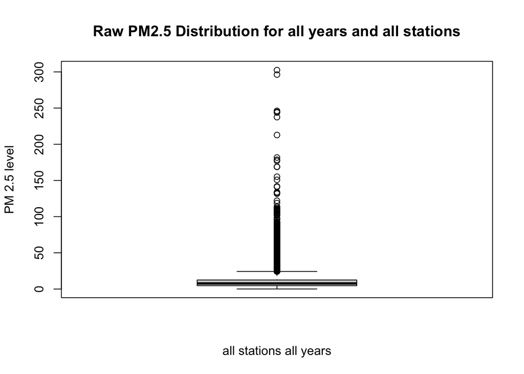

```r
boxplot(filter_combo$mean_pm25, main='Raw PM2.5 Distribution for all years and all stations', ylab='PM 2.5 level', xlab='all stations all years')
```

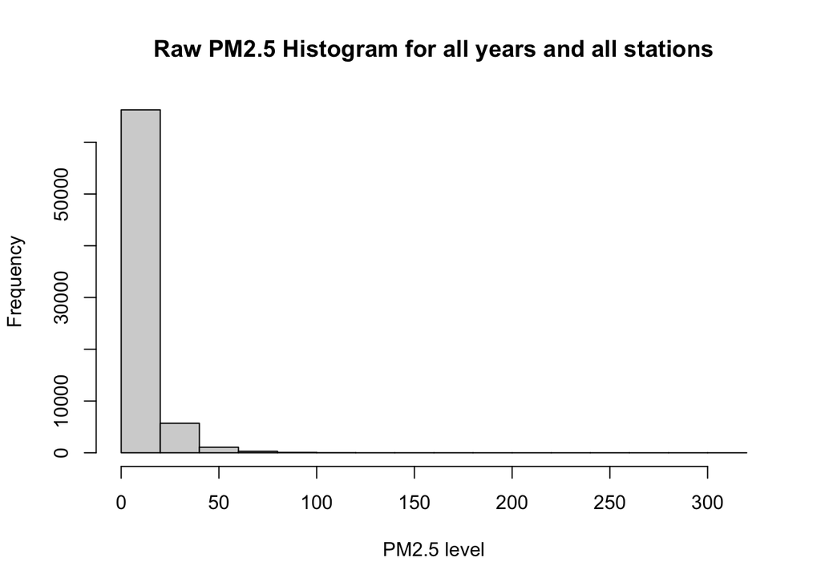

```r
hist(filter_combo$mean_pm25, main='Raw PM2.5 Histogram for all years and all stations', xlab='PM2.5 level', ylab='Frequency')
```

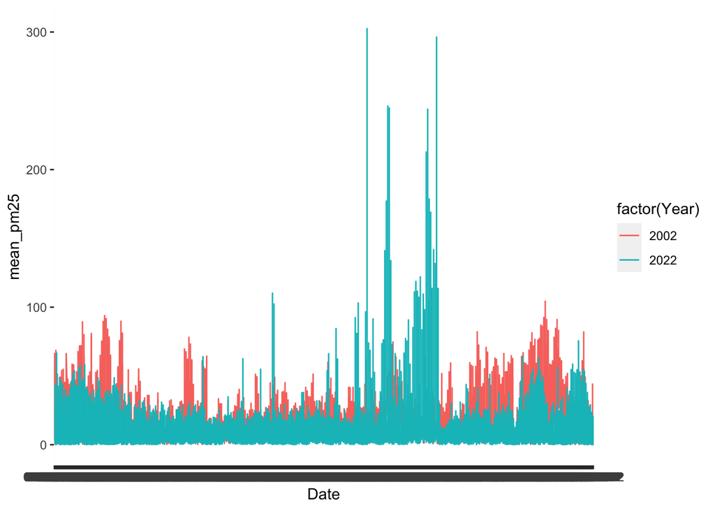

```r
#Plot 1
ggplot(filter_combo, aes(x = Date, y = mean_pm25,
      color = factor(Year), group = factor(Year))) +
      geom_line()
```

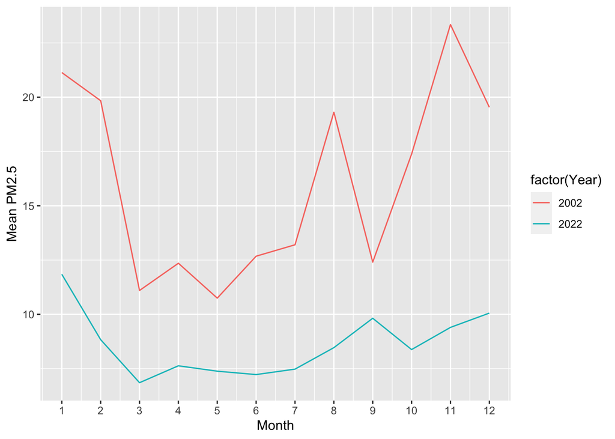

```r
monthly_means <- filter_combo %>%
  group_by(Year, Month) %>%
  summarize(mean_pm25 = mean(mean_pm25, na.rm = TRUE))
# Create the plot
ggplot(monthly_means, aes(x = Month, y = mean_pm25, color = factor(Year), group = factor(Year))) +
  geom_line() +
  scale_x_continuous(breaks = 1:12) +
  labs(x = "Month", y = "Mean PM2.5")
```

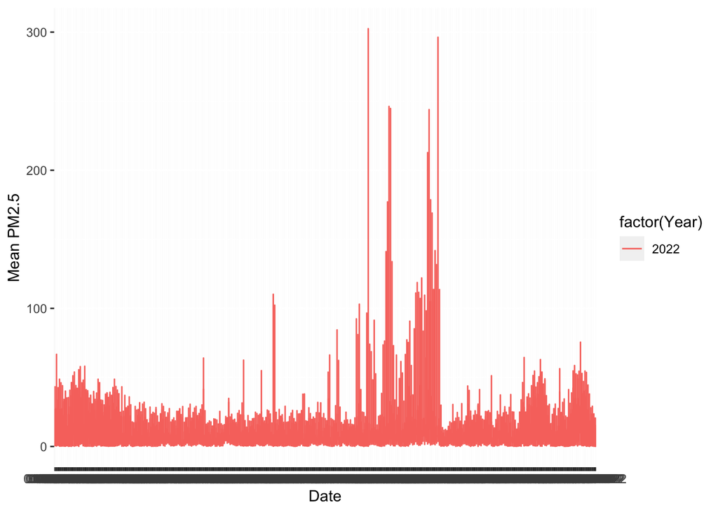

```r
# 2022 only
filtered_combo22 <- filter_combo %>% filter(Year == 2022)

ggplot(filtered_combo22, aes(x = Date, y = mean_pm25, color = factor(Year), group = factor(Year))) +
  geom_line() +
  labs(x = "Date", y = "Mean PM2.5")
```

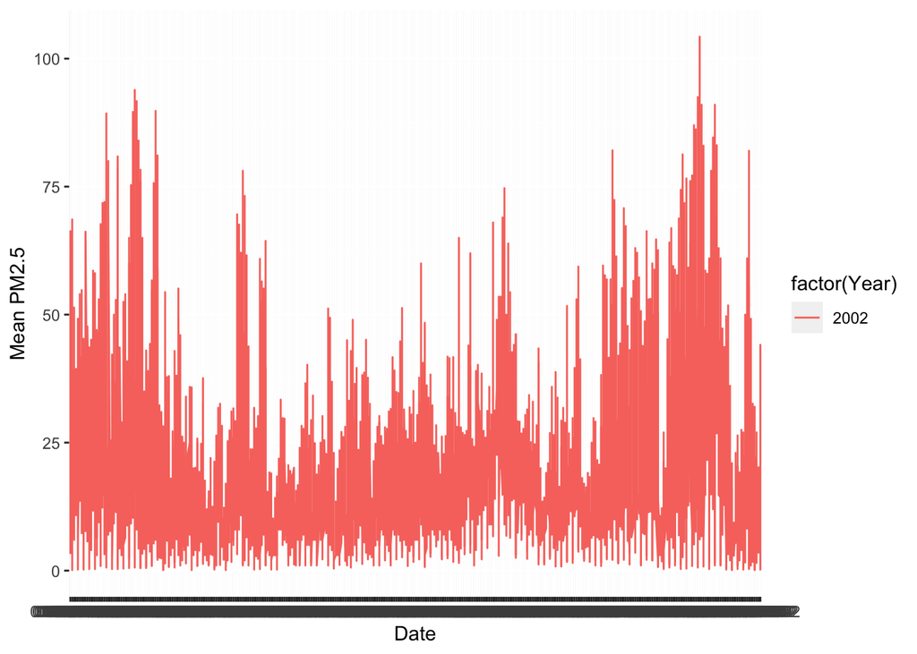

```r
# 2002 only
filtered_combo02 <- filter_combo %>% filter(Year == 2002)

ggplot(filtered_combo02, aes(x = Date, y = mean_pm25, color = factor(Year), group = factor(Year))) +
  geom_line() +
  labs(x = "Date", y = "Mean PM2.5")
```

## 5. Explore.

Create exploratory plots (e.g. boxplots, histograms, line plots) and summary statistics that best suit each level of data. Be sure to write up explanations of what you observe in these data. The primary question you will answer is whether daily concentrations of PM2.5 (particulate matter air pollution with aerodynamic diameter less than 2.5 `\(\mu\)`m) have decreased in California over the last 20 years (from 2002 to 2022).

state

county

site in Los Angeles

```r
length(unique(combo$COUNTY))
```

```
[1] 51
```

```r
#there are 51 counties

la_combo <- subset(filter_combo, COUNTY == 'Los Angeles')
length(unique(la_combo$site))
```

```
[1] 18
```

```r
#there are 18 sites in los angeles
```

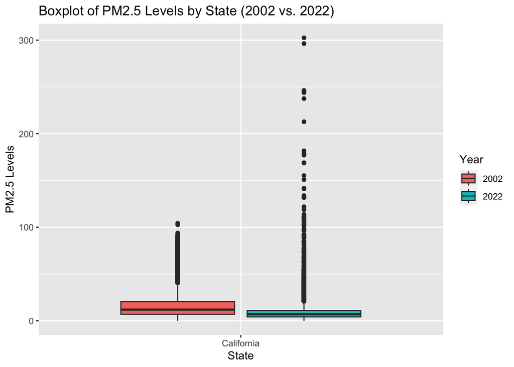

```r
#State Level
ggplot(filter_combo, aes(x = STATE, y = mean_pm25, fill = factor(Year))) +
  geom_boxplot() +
  labs(x = "State", y = "PM2.5 Levels", fill = "Year") +
  ggtitle("Boxplot of PM2.5 Levels by State (2002 vs. 2022)")
```

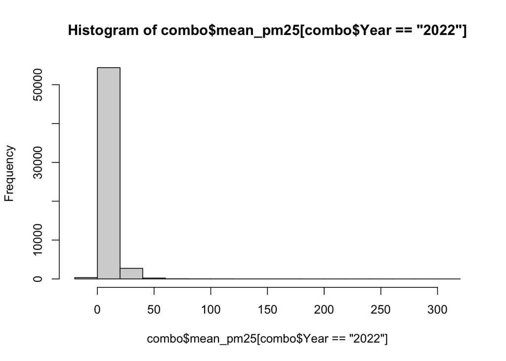

```r
hist(combo$mean_pm25[combo$Year=='2022'])
```

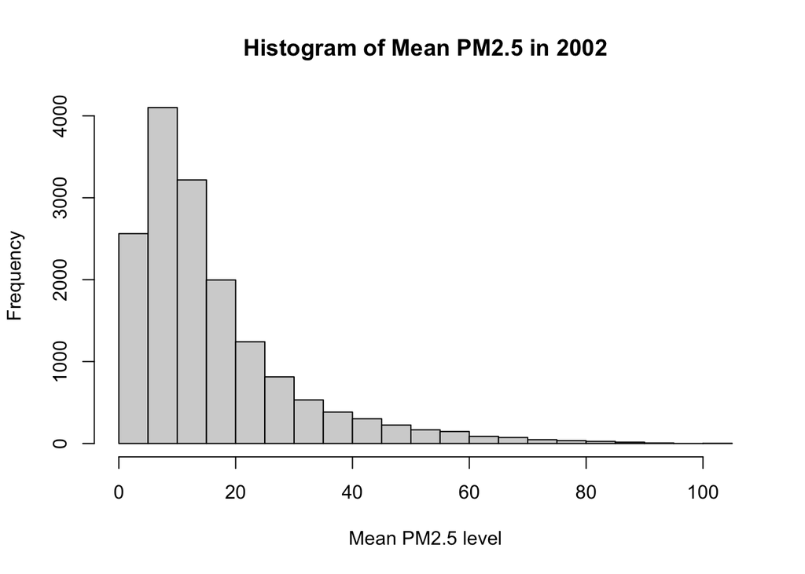

```r
# Create the histogram plot
hist_data02 <- combo$mean_pm25[combo$Year == '2002']
hist(hist_data02,
     main = 'Histogram of Mean PM2.5 in 2002',
     ylab = 'Frequency',
     xlab = 'Mean PM2.5 level')
```

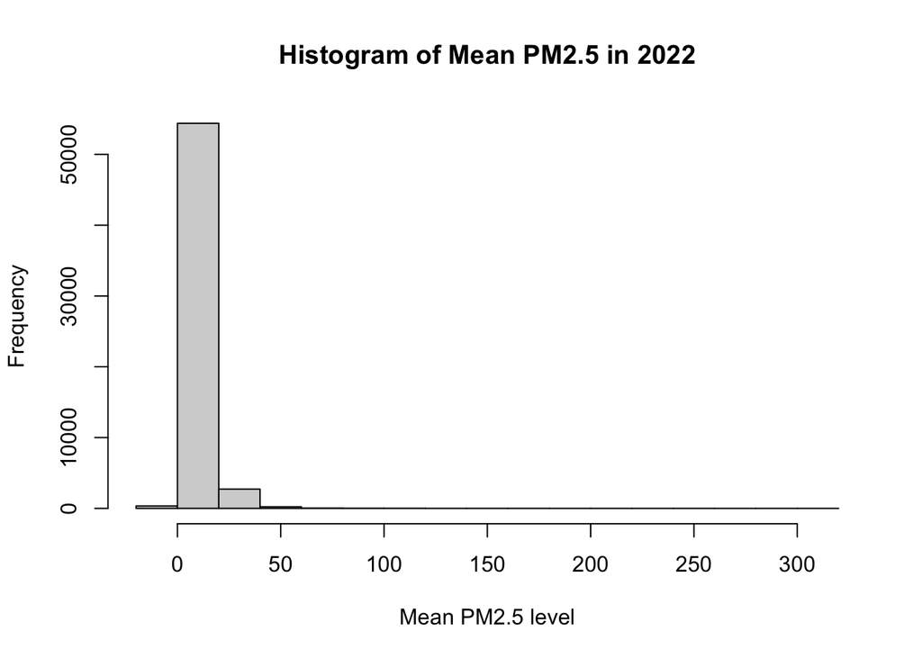

```r
hist_data22 <- combo$mean_pm25[combo$Year == '2022']
hist(hist_data22,
     main = 'Histogram of Mean PM2.5 in 2022',
     ylab = 'Frequency',
     xlab = 'Mean PM2.5 level')
```

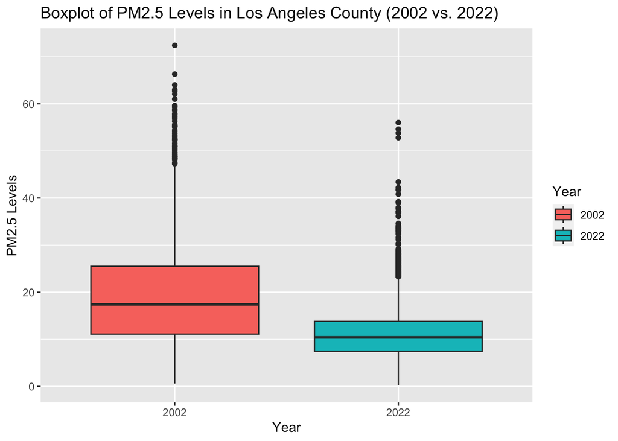

```r
# county level
ggplot(la_combo, aes(x = factor(Year), y = mean_pm25, fill = factor(Year))) +
  geom_boxplot() +
  labs(x = "Year", y = "PM2.5 Levels", fill = "Year") +
  ggtitle("Boxplot of PM2.5 Levels in Los Angeles County (2002 vs. 2022)")
```

[figure not shown]

```r
hist_county_02 <- combo$mean_pm25[combo$Year == '2002']
hist(hist_county_02,
     main = 'Histogram of Mean PM2.5 in 2002 in LA County',
     ylab = 'Frequency',
     xlab = 'Mean PM2.5 level')
```